# 50 LYS SIDE_0_0.1_10_Density

## Sample=1ls9-a:32:cd-a:32:cg-a:32:ce

| pdb_code | central atom | ca density | parallel atom | pa density | planar atom | pl density |
| --- | --- | --- | --- | --- | --- | --- |
| 1ls9 | [10.27, 27.7, 15.22] | 102.4207 | [10.16, 27.63, 13.68] | 107.6393 | [11.51, 28.5, 15.56] | 106.9077 |

## Slices along x,y and z

Sliced x-wise

Sliced y-wise

Sliced z-wise

50/101

50/101

50/101

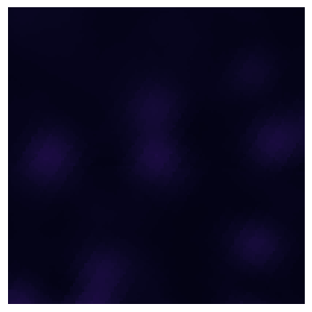

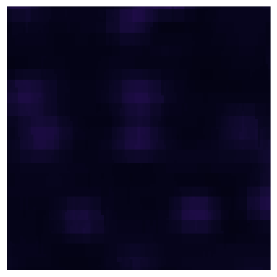

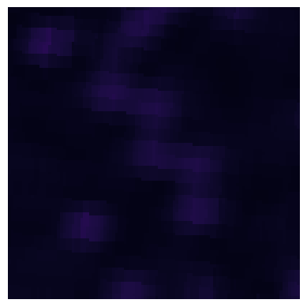

## Sample=6sao-a:77:cd-a:77:cg-a:77:ce

| pdb_code | central atom | ca density | parallel atom | pa density | planar atom | pl density |
| --- | --- | --- | --- | --- | --- | --- |
| 6sao | [-31.73, -20.75, 9.1] | 106.1871 | [-30.62, -20.06, 8.32] | 116.4872 | [-32.24, -22.0, 8.4] | 96.8193 |

## Slices along x,y and z

Sliced x-wise

Sliced y-wise

Sliced z-wise

50/101

50/101

50/101

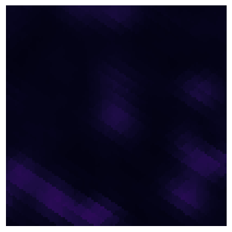

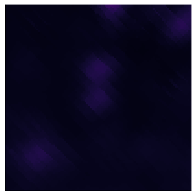

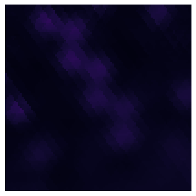

## Sample=4rqa-a:179:cd-a:179:cg-a:179:ce

| pdb_code | central atom | ca density | parallel atom | pa density | planar atom | pl density |
| --- | --- | --- | --- | --- | --- | --- |
| 4rqa | [7.2, 39.18, 29.64] | 78.4639 | [7.1, 37.81, 28.99] | 83.1489 | [7.58, 39.11, 31.11] | 67.0054 |

## Slices along x,y and z

Sliced x-wise

Sliced y-wise

Sliced z-wise

50/101

50/101

50/101

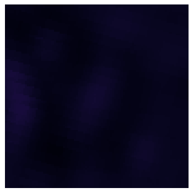

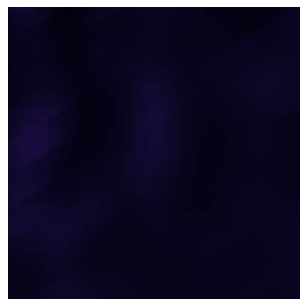

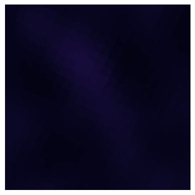

## Sample=4ate-a:84:cd-a:84:cg-a:84:ce

| pdb_code | central atom | ca density | parallel atom | pa density | planar atom | pl density |
| --- | --- | --- | --- | --- | --- | --- |
| 4ate | [10.61, -41.06, -24.85] | 122.3202 | [9.15, -40.41, -24.5] | 132.9542 | [10.7, -41.7, -26.13] | 94.42 |

## Slices along x,y and z

Sliced x-wise

Sliced y-wise

Sliced z-wise

50/101

50/101

50/101

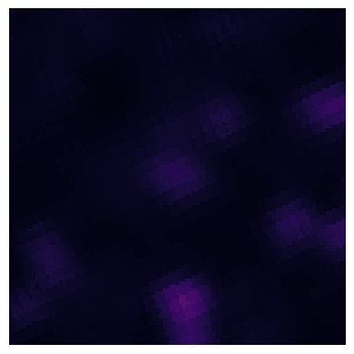

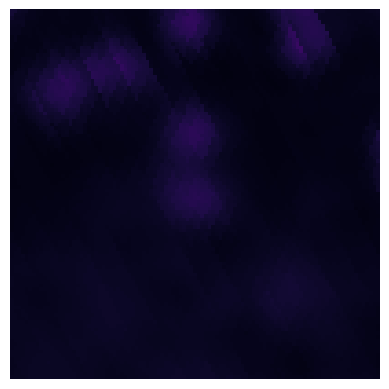

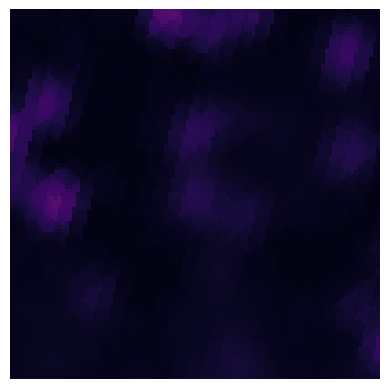

## Sample=4dd5-a:341:cd-a:341:cg-a:341:ce

| pdb_code | central atom | ca density | parallel atom | pa density | planar atom | pl density |
| --- | --- | --- | --- | --- | --- | --- |
| 4dd5 | [42.72, 25.14, 35.46] | 102.1839 | [42.9, 25.27, 36.98] | 107.0422 | [44.06, 25.14, 34.74] | 105.1849 |

## Slices along x,y and z

Sliced x-wise

Sliced y-wise

Sliced z-wise

50/101

50/101

50/101

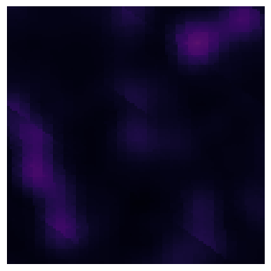

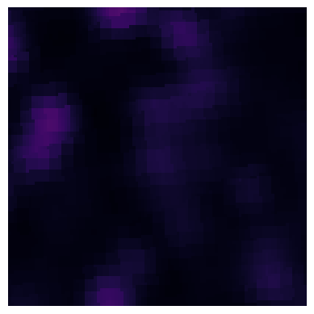

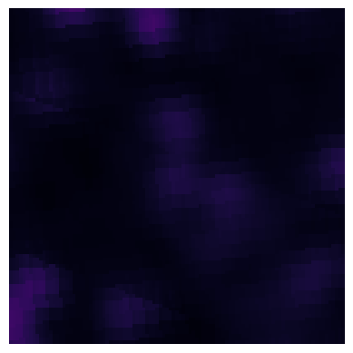

## Sample=3ayx-a:310:cd-a:310:cg-a:310:ce

| pdb_code | central atom | ca density | parallel atom | pa density | planar atom | pl density |
| --- | --- | --- | --- | --- | --- | --- |
| 3ayx | [15.58, 12.03, -0.89] | 85.3611 | [14.38, 11.03, -0.74] | 77.8565 | [16.69, 11.41, -0.02] | 83.4946 |

## Slices along x,y and z

Sliced x-wise

Sliced y-wise

Sliced z-wise

50/101

50/101

50/101

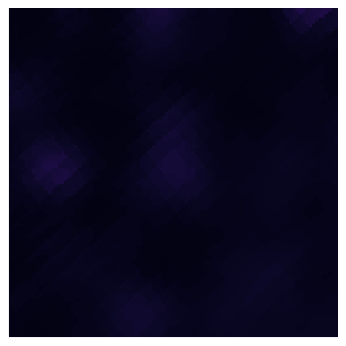

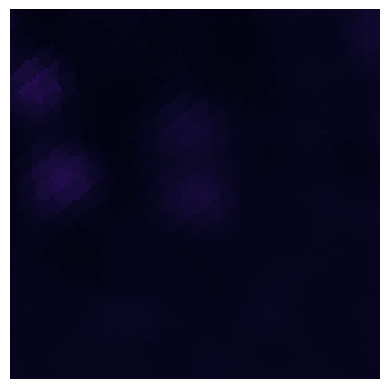

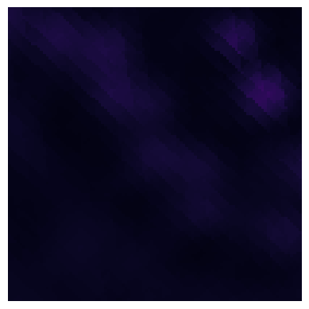

## Sample=5sui-a:207:cd-a:207:cg-a:207:ce

| pdb_code | central atom | ca density | parallel atom | pa density | planar atom | pl density |
| --- | --- | --- | --- | --- | --- | --- |
| 5sui | [22.53, 50.59, 36.01] | 73.1231 | [21.28, 50.68, 36.8] | 76.2091 | [22.72, 51.81, 35.17] | 69.9561 |

## Slices along x,y and z

Sliced x-wise

Sliced y-wise

Sliced z-wise

50/101

50/101

50/101

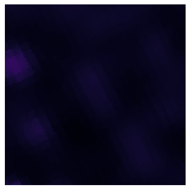

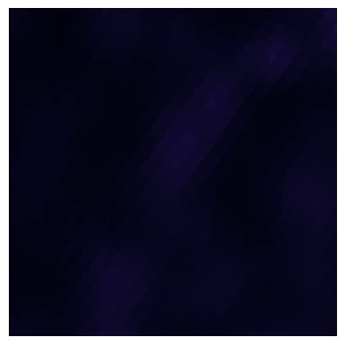

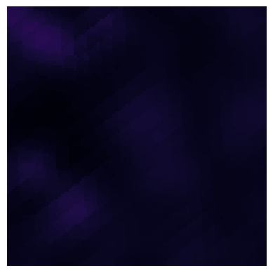

## Sample=6lac-a:173:cd-a:173:cg-a:173:ce

| pdb_code | central atom | ca density | parallel atom | pa density | planar atom | pl density |
| --- | --- | --- | --- | --- | --- | --- |
| 6lac | [-27.65, -24.43, -3.77] | 69.0028 | [-26.31, -23.85, -3.36] | 78.6285 | [-28.65, -23.41, -4.27] | 63.2452 |

## Slices along x,y and z

Sliced x-wise

Sliced y-wise

Sliced z-wise

50/101

50/101

50/101

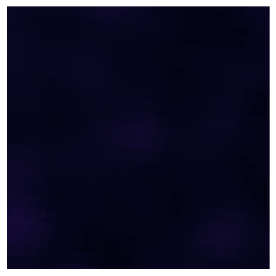

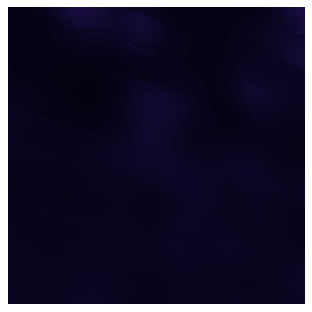

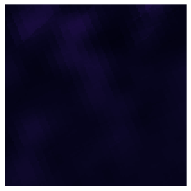

## Sample=1moo-a:252:cd-a:252:cg-a:252:ce

| pdb_code | central atom | ca density | parallel atom | pa density | planar atom | pl density |
| --- | --- | --- | --- | --- | --- | --- |
| 1moo | [3.27, -1.34, 32.5] | 71.2989 | [2.22, -2.26, 33.01] | 73.2359 | [4.32, -2.12, 31.7] | 69.1401 |

## Slices along x,y and z

Sliced x-wise

Sliced y-wise

Sliced z-wise

50/101

50/101

50/101

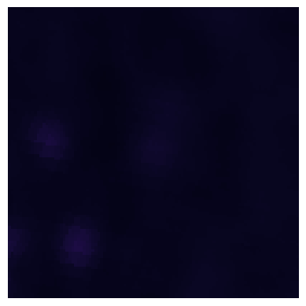

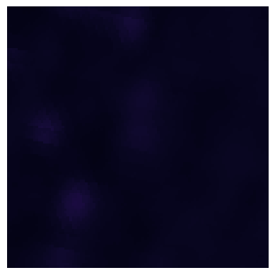

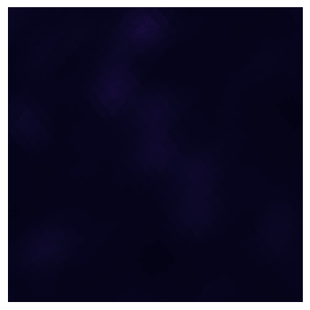

## Sample=2g7b-a:20:cd-a:20:cg-a:20:ce

| pdb_code | central atom | ca density | parallel atom | pa density | planar atom | pl density |
| --- | --- | --- | --- | --- | --- | --- |
| 2g7b | [-18.33, -7.7, 30.86] | 112.0621 | [-17.54, -6.52, 30.3] | 113.1689 | [-17.95, -8.03, 32.29] | 94.136 |

## Slices along x,y and z

Sliced x-wise

Sliced y-wise

Sliced z-wise

50/101

50/101

50/101

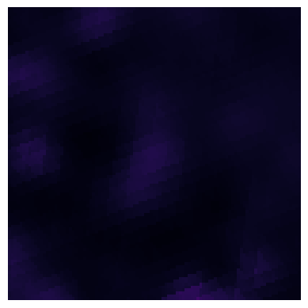

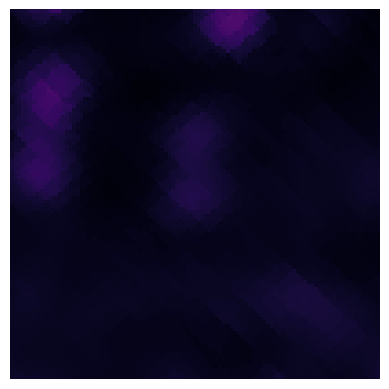

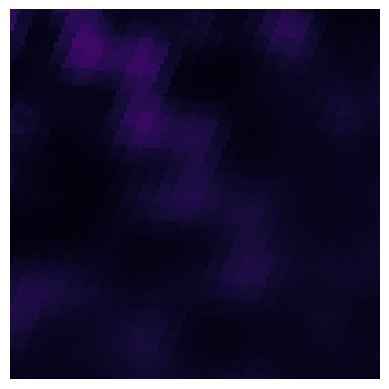

## Sample=1gwm-a:12:cd-a:12:cg-a:12:ce

| pdb_code | central atom | ca density | parallel atom | pa density | planar atom | pl density |
| --- | --- | --- | --- | --- | --- | --- |
| 1gwm | [40.01, -12.25, 5.2] | 68.9547 | [39.59, -11.65, 6.55] | 88.1868 | [40.13, -11.14, 4.13] | 71.4966 |

## Slices along x,y and z

Sliced x-wise

Sliced y-wise

Sliced z-wise

50/101

50/101

50/101

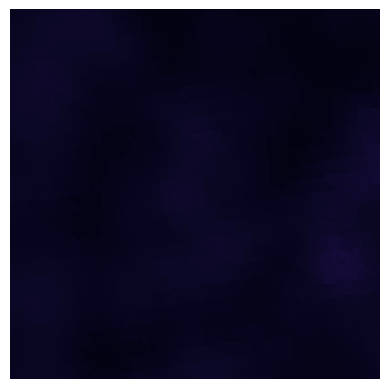

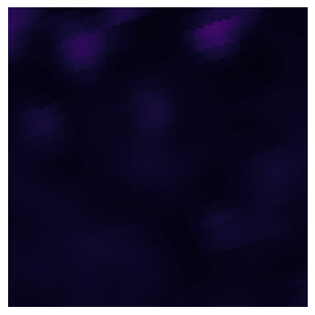

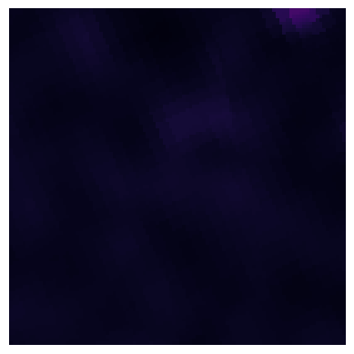

## Sample=1n3l-a:310:cd-a:310:cg-a:310:ce

| pdb_code | central atom | ca density | parallel atom | pa density | planar atom | pl density |
| --- | --- | --- | --- | --- | --- | --- |
| 1n3l | [40.28, 30.41, 35.79] | 89.9994 | [40.74, 31.57, 34.97] | 126.79 | [39.0, 30.6, 36.53] | 108.4988 |

## Slices along x,y and z

Sliced x-wise

Sliced y-wise

Sliced z-wise

50/101

50/101

50/101

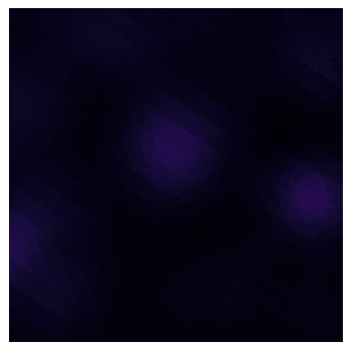

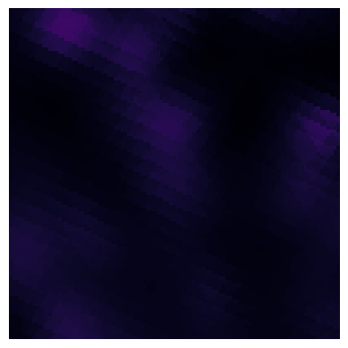

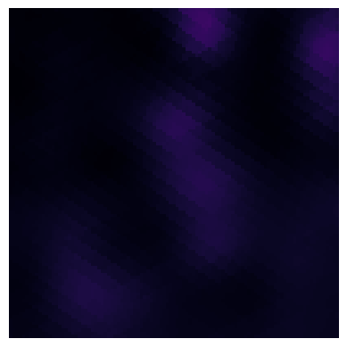

## Sample=2vxn-a:13:cd-a:13:cg-a:13:ce

| pdb_code | central atom | ca density | parallel atom | pa density | planar atom | pl density |
| --- | --- | --- | --- | --- | --- | --- |
| 2vxn | [31.39, -1.45, 12.66] | 133.8671 | [31.26, -0.26, 13.61] | 136.3749 | [30.01, -1.89, 12.21] | 134.0299 |

## Slices along x,y and z

Sliced x-wise

Sliced y-wise

Sliced z-wise

50/101

50/101

50/101

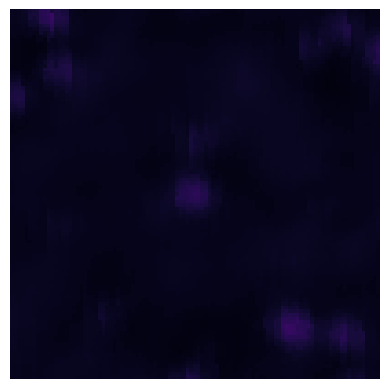

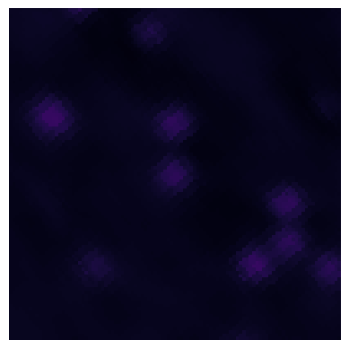

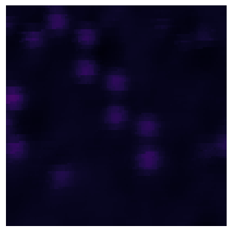

## Sample=5aov-a:170:cd-a:170:cg-a:170:ce

| pdb_code | central atom | ca density | parallel atom | pa density | planar atom | pl density |
| --- | --- | --- | --- | --- | --- | --- |
| 5aov | [115.36, 53.01, -1.6] | 105.9511 | [116.33, 53.47, -0.53] | 102.4355 | [115.81, 53.64, -2.88] | 88.4137 |

## Slices along x,y and z

Sliced x-wise

Sliced y-wise

Sliced z-wise

50/101

50/101

50/101

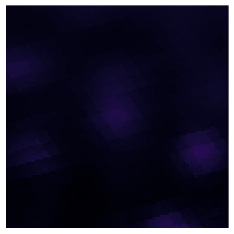

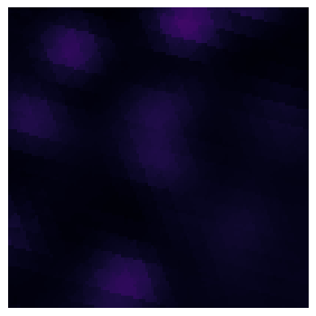

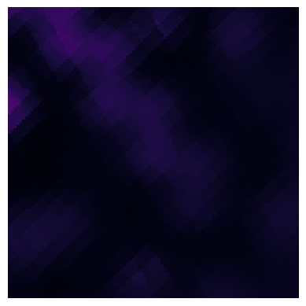

## Sample=2ij2-a:15:cd-a:15:cg-a:15:ce

| pdb_code | central atom | ca density | parallel atom | pa density | planar atom | pl density |
| --- | --- | --- | --- | --- | --- | --- |
| 2ij2 | [24.47, 3.27, 39.67] | 81.936 | [24.31, 4.76, 39.6] | 92.1017 | [23.75, 2.58, 38.51] | 82.2238 |

## Slices along x,y and z

Sliced x-wise

Sliced y-wise

Sliced z-wise

50/101

50/101

50/101

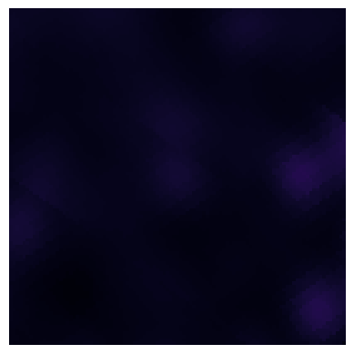

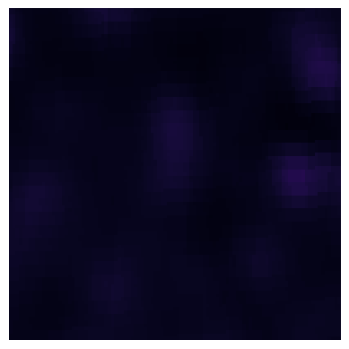

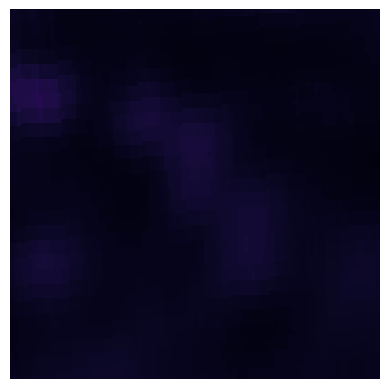